# Introduction to padr

Author

Rick Dean

Abstract

The following R scripts are from padr’s vignette [Introduction to padr](https://cran.r-project.org/web/packages/padr/vignettes/padr.html).

```r
library(padr)
library(data.table)
library(ggplot2)
library(magrittr)
```

# 1 Introduction to padr

## 1.1 Modify the coffee dataset time stamp

Set coffee data set as data.table.

```r
coffee_dt <- data.table::setDT(padr::coffee)
str(coffee_dt)
```

```
Classes 'data.table' and 'data.frame':  4 obs. of  2 variables:
 $ time_stamp: POSIXct, format: "2016-07-07 09:11:21" "2016-07-07 09:46:48" ...
 $ amount    : num  3.14 2.98 4.11 3.14
 - attr(*, ".internal.selfref")=<externalptr>
```

Thicken the *time_stamp* variable to a higher interval of “day”.

```r
new_coffee_dt <- coffee_dt %>%
  padr::thicken(interval = "day")
head(new_coffee_dt)
```

```
            time_stamp amount time_stamp_day
1: 2016-07-07 09:11:21   3.14     2016-07-07
2: 2016-07-07 09:46:48   2.98     2016-07-07
3: 2016-07-09 13:25:17   4.11     2016-07-09
4: 2016-07-10 10:45:11   3.14     2016-07-10
```

Pad the *time_stamp_day* variable by filling in missing days.

```r
new_coffee_dt <- new_coffee_dt %>%
  padr::pad(by = "time_stamp_day")
```

```
pad applied on the interval: day
```

```r
head(new_coffee_dt)
```

```
            time_stamp amount time_stamp_day
1: 2016-07-07 09:11:21   3.14     2016-07-07
2: 2016-07-07 09:46:48   2.98     2016-07-07
3:                <NA>     NA     2016-07-08
4: 2016-07-09 13:25:17   4.11     2016-07-09
5: 2016-07-10 10:45:11   3.14     2016-07-10
```

Fill the NA observations with values.

```r
new_coffee_dt <- new_coffee_dt %>%
  padr::fill_by_value(amount, value = 0)
head(new_coffee_dt)
```

```
            time_stamp amount time_stamp_day
1: 2016-07-07 09:11:21   3.14     2016-07-07
2: 2016-07-07 09:46:48   2.98     2016-07-07
3:                <NA>   0.00     2016-07-08
4: 2016-07-09 13:25:17   4.11     2016-07-09
5: 2016-07-10 10:45:11   3.14     2016-07-10
```

Group *time_stamp_day* variable and aggregate by adding a sum variable:

```r
new_coffee_grouped_dt <- new_coffee_dt[,.(day_amount = sum(amount)),by = .(time_stamp_day)]
head(new_coffee_grouped_dt)
```

```
   time_stamp_day day_amount
1:     2016-07-07       6.12
2:     2016-07-08       0.00
3:     2016-07-09       4.11
4:     2016-07-10       3.14
```

Plot the data.

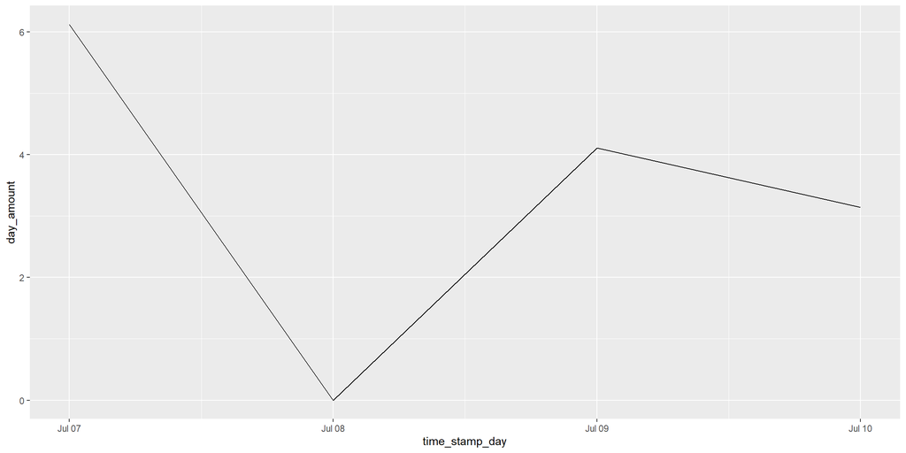

```r
ggplot2::ggplot(data = new_coffee_grouped_dt, aes(x = time_stamp_day, y = day_amount)) +
  geom_line()
```

## 1.2 Specify interval with thicken

Set up the data set.

```r
day_data_dt <- data.table(day_var = as.Date(c("2016-08-12", "2016-08-13", "2016-08-26", "2016-08-29")))
head(day_data_dt)
```

```
      day_var
1: 2016-08-12
2: 2016-08-13
3: 2016-08-26
4: 2016-08-29
```

Thicken with interval = “week”.

```r
week_data_dt <- day_data_dt %>%
  padr::thicken(interval = "week")
head(week_data_dt)
```

```
      day_var day_var_week
1: 2016-08-12   2016-08-07
2: 2016-08-13   2016-08-07
3: 2016-08-26   2016-08-21
4: 2016-08-29   2016-08-28
```

Thicken with interval = “4 days”.

```r
four_day_data_dt <- day_data_dt %>%
  padr::thicken(interval = "4 days")
head(four_day_data_dt)
```

```
      day_var day_var_4_day
1: 2016-08-12    2016-08-11
2: 2016-08-13    2016-08-11
3: 2016-08-26    2016-08-23
4: 2016-08-29    2016-08-27
```

### 1.2.1 Further refinement using thicken’s start_val

Set up the data set:

```r
emergency_dt <- data.table::setDT(padr::emergency)
str(emergency_dt)
```

```
Classes 'data.table' and 'data.frame':  120450 obs. of  6 variables:
 $ lat       : num  40.3 40.3 40.1 40.1 40.3 ...
 $ lng       : num  -75.6 -75.3 -75.4 -75.3 -75.6 ...
 $ zip       : int  19525 19446 19401 19401 NA 19446 19044 19426 19438 19462 ...
 $ title     : chr  "EMS: BACK PAINS/INJURY" "EMS: DIABETIC EMERGENCY" "Fire: GAS-ODOR/LEAK" "EMS: CARDIAC EMERGENCY" ...
 $ time_stamp: POSIXct, format: "2015-12-10 17:40:00" "2015-12-10 17:40:00" ...
 $ twp       : chr  "NEW HANOVER" "HATFIELD TOWNSHIP" "NORRISTOWN" "NORRISTOWN" ...
 - attr(*, ".internal.selfref")=<externalptr>
```

Filter by title.

```r
emergency_overdose_dt <- emergency_dt[title == "EMS: OVERDOSE",]
head(emergency_overdose_dt[, .(lat, lng, time_stamp)], n = 10)
```

```
         lat       lng          time_stamp
 1: 40.15090 -75.12744 2015-12-10 22:32:01
 2: 40.15583 -75.36521 2015-12-11 17:07:01
 3: 40.00971 -75.29040 2015-12-12 16:52:01
 4: 40.15090 -75.12744 2015-12-12 19:07:01
 5: 40.31629 -75.55367 2015-12-12 19:57:01
 6: 40.11121 -75.42619 2015-12-13 00:27:01
 7: 40.11121 -75.42619 2015-12-13 00:28:00
 8: 40.24730 -75.65523 2015-12-13 03:16:01
 9: 40.14148 -75.11714 2015-12-13 13:46:01
10: 40.14279 -75.11960 2015-12-13 13:47:00
```

Thicken with *interval* = “day” and *start_val* = “2015-12-11 08:00:00”.

```r
emergency_overdose_dt <- emergency_overdose_dt %>%
  padr::thicken(
    interval = "day",
    start_val = as.POSIXct("2015-12-11 08:00:00", tz="EST"),
    colname = "daystart"
  )
head(emergency_overdose_dt[, .(lat, lng, time_stamp, daystart)], n = 10)
```

```
         lat       lng          time_stamp            daystart
 1: 40.15583 -75.36521 2015-12-11 17:07:01 2015-12-11 08:00:00
 2: 40.00971 -75.29040 2015-12-12 16:52:01 2015-12-12 08:00:00
 3: 40.15090 -75.12744 2015-12-12 19:07:01 2015-12-12 08:00:00
 4: 40.31629 -75.55367 2015-12-12 19:57:01 2015-12-12 08:00:00
 5: 40.11121 -75.42619 2015-12-13 00:27:01 2015-12-12 08:00:00
 6: 40.11121 -75.42619 2015-12-13 00:28:00 2015-12-12 08:00:00
 7: 40.24730 -75.65523 2015-12-13 03:16:01 2015-12-12 08:00:00
 8: 40.14148 -75.11714 2015-12-13 13:46:01 2015-12-13 08:00:00
 9: 40.14279 -75.11960 2015-12-13 13:47:00 2015-12-13 08:00:00
10: 40.11621 -75.12075 2015-12-13 14:32:00 2015-12-13 08:00:00
```

Group by daystart and get a count for each day.

```r
emergency_overdose_grouped_dt <- emergency_overdose_dt[, .(lat, lng, nr_od = .N), by = .(daystart)]
head(emergency_overdose_grouped_dt, n = 10)
```

```
               daystart      lat       lng nr_od
 1: 2015-12-11 08:00:00 40.15583 -75.36521     1
 2: 2015-12-12 08:00:00 40.00971 -75.29040     6
 3: 2015-12-12 08:00:00 40.15090 -75.12744     6
 4: 2015-12-12 08:00:00 40.31629 -75.55367     6
 5: 2015-12-12 08:00:00 40.11121 -75.42619     6
 6: 2015-12-12 08:00:00 40.11121 -75.42619     6
 7: 2015-12-12 08:00:00 40.24730 -75.65523     6
 8: 2015-12-13 08:00:00 40.14148 -75.11714     7
 9: 2015-12-13 08:00:00 40.14279 -75.11960     7
10: 2015-12-13 08:00:00 40.11621 -75.12075     7
```

## 1.3 Specify pad

Set up the data set.

```r
account_data_dt <- data.table(day = as.Date(c("2016-10-21", "2016-10-23", "2016-10-26")),
                           balance = c(304.46, 414.76, 378.98))
head(account_data_dt)
```

```
          day balance
1: 2016-10-21  304.46
2: 2016-10-23  414.76
3: 2016-10-26  378.98
```

Apply *pad()* with interval of day.

```r
account_data_padded_dt <- account_data_dt %>%
  pad()
```

```
pad applied on the interval: day
```

```r
head(account_data_padded_dt)
```

```
          day balance
1: 2016-10-21  304.46
2: 2016-10-22      NA
3: 2016-10-23  414.76
4: 2016-10-24      NA
5: 2016-10-25      NA
6: 2016-10-26  378.98
```

Fill NA’s with last value.

```r
data.table::setnafill(account_data_padded_dt, type = "locf", cols = "balance")
head(account_data_padded_dt)
```

```
          day balance
1: 2016-10-21  304.46
2: 2016-10-22  304.46
3: 2016-10-23  414.76
4: 2016-10-24  414.76
5: 2016-10-25  414.76
6: 2016-10-26  378.98
```

Specify a lower interval than the one of the variable, using *pad* as the inverse of *thicken*.

```r
account_data_hour_dt <- account_data_dt %>%
  padr::pad(interval = "hour", start_val = as.POSIXct("2016-10-20 22:00:00"))
head(account_data_hour_dt, n = 10)
```

```
                    day balance
 1: 2016-10-20 22:00:00      NA
 2: 2016-10-20 23:00:00      NA
 3: 2016-10-21 00:00:00  304.46
 4: 2016-10-21 01:00:00      NA
 5: 2016-10-21 02:00:00      NA
 6: 2016-10-21 03:00:00      NA
 7: 2016-10-21 04:00:00      NA
 8: 2016-10-21 05:00:00      NA
 9: 2016-10-21 06:00:00      NA
10: 2016-10-21 07:00:00      NA
```

### 1.3.1 Using the grouping argument of *pad*

Set up the data set.

```r
grouping_dt <- data.table(
  group = rep(c("A","B"), c(3,3)),
  date = as.Date(c("2017-10-02", "2017-10-04", "2017-10-06", "2017-10-01", "2017-10-03", "2017-10-04")),
  value = rep(2,6)
)
head(grouping_dt)
```

```
   group       date value
1:     A 2017-10-02     2
2:     A 2017-10-04     2
3:     A 2017-10-06     2
4:     B 2017-10-01     2
5:     B 2017-10-03     2
6:     B 2017-10-04     2
```

Use *pad()* to group with an interval of “day”. Note that when interval is not specified, it will be determined applying `get_interval()` on datetime variable as a whole.

```r
grouping_dt <- grouping_dt %>%
  pad(group = "group")
```

```
pad applied on the interval: day
```

```r
head(grouping_dt, n = 10)
```

```
   group       date value
1:     A 2017-10-02     2
2:     A 2017-10-03    NA
3:     A 2017-10-04     2
4:     A 2017-10-05    NA
5:     A 2017-10-06     2
6:     B 2017-10-01     2
7:     B 2017-10-02    NA
8:     B 2017-10-03     2
9:     B 2017-10-04     2
```

### 1.3.2 Using fill functions with *pad*

1. Set up the data set:

```r
counts_dt <- data.table(x = as.Date(c("2016-11-21", "2016-11-23", "2016-11-24")), y = c(2, 4, 4))
head(counts_dt)
```

```
            x y
1: 2016-11-21 2
2: 2016-11-23 4
3: 2016-11-24 4
```

Apply pad and fill NA’s (note: interval for *pad()* is “day” and default value is 0).

```r
counts_filled_dt <- counts_dt %>%
  padr::pad() %>%
  padr::fill_by_value(y)
```

```
pad applied on the interval: day
```

```r
head(counts_filled_dt)
```

```
            x y
1: 2016-11-21 2
2: 2016-11-22 0
3: 2016-11-23 4
4: 2016-11-24 4
```

Fill with a specific value = 42:

```r
counts_filled_dt <- counts_dt %>%
  padr::pad() %>%
  padr::fill_by_value(y,value = 42)
```

```
pad applied on the interval: day
```

```r
head(counts_filled_dt)
```

```
            x  y
1: 2016-11-21  2
2: 2016-11-22 42
3: 2016-11-23  4
4: 2016-11-24  4
```

Fill with the function *mean()*.

```r
counts_filled_dt <- counts_dt %>%
  padr::pad() %>%
  padr::fill_by_function(y,fun = mean)
```

```
pad applied on the interval: day
```

```r
head(counts_filled_dt)
```

```
            x        y
1: 2016-11-21 2.000000
2: 2016-11-22 3.333333
3: 2016-11-23 4.000000
4: 2016-11-24 4.000000
```

Fill by prevalence.

```r
counts_filled_dt <- counts_dt %>%
  padr::pad() %>%
  padr::fill_by_prevalent(y)
```

```
pad applied on the interval: day
```

```r
head(counts_filled_dt)
```

```
            x y
1: 2016-11-21 2
2: 2016-11-22 4
3: 2016-11-23 4
4: 2016-11-24 4
```

## 1.4 Formatting functions

### 1.4.1 Using *center_interval()*

Set up the data set:

```r
emergency_dt <- data.table::setDT(padr::emergency)
head(emergency_dt[, .(lat, lng, time_stamp)], n = 10)
```

```
         lat       lng          time_stamp
 1: 40.29788 -75.58129 2015-12-10 17:40:00
 2: 40.25806 -75.26468 2015-12-10 17:40:00
 3: 40.12118 -75.35198 2015-12-10 17:40:00
 4: 40.11615 -75.34351 2015-12-10 17:40:01
 5: 40.25149 -75.60335 2015-12-10 17:40:01
 6: 40.25347 -75.28324 2015-12-10 17:40:01
 7: 40.18211 -75.12780 2015-12-10 17:40:01
 8: 40.21729 -75.40518 2015-12-10 17:40:01
 9: 40.28903 -75.39959 2015-12-10 17:40:01
10: 40.10240 -75.29146 2015-12-10 17:40:01
```

Thicken *time_stamp* to a higher interval of “hour”.

```r
emergency_dt <- emergency_dt %>%
  padr::thicken(interval = "hour", colname = "h")
head(emergency_dt[, .(lat, lng, time_stamp, h)], n = 10)
```

```
         lat       lng          time_stamp                   h
 1: 40.29788 -75.58129 2015-12-10 17:40:00 2015-12-10 17:00:00
 2: 40.25806 -75.26468 2015-12-10 17:40:00 2015-12-10 17:00:00
 3: 40.12118 -75.35198 2015-12-10 17:40:00 2015-12-10 17:00:00
 4: 40.11615 -75.34351 2015-12-10 17:40:01 2015-12-10 17:00:00
 5: 40.25149 -75.60335 2015-12-10 17:40:01 2015-12-10 17:00:00
 6: 40.25347 -75.28324 2015-12-10 17:40:01 2015-12-10 17:00:00
 7: 40.18211 -75.12780 2015-12-10 17:40:01 2015-12-10 17:00:00
 8: 40.21729 -75.40518 2015-12-10 17:40:01 2015-12-10 17:00:00
 9: 40.28903 -75.39959 2015-12-10 17:40:01 2015-12-10 17:00:00
10: 40.10240 -75.29146 2015-12-10 17:40:01 2015-12-10 17:00:00
```

Count the number in each hour.

```r
emergency_hour_count_dt <- emergency_dt[, .(hour_count = .N), by = .(h)]
head(emergency_hour_count_dt)
```

```
                     h hour_count
1: 2015-12-10 17:00:00         22
2: 2015-12-10 18:00:00         28
3: 2015-12-10 19:00:00         22
4: 2015-12-10 20:00:00         15
5: 2015-12-10 21:00:00          9
6: 2015-12-10 22:00:00         12
```

Take the first 24 hours and create a new variable that centers the hours using *center_interval()*.

```r
emergency_hour_count_dt[1:24, h_center := padr::center_interval(h)]
head(emergency_hour_count_dt)
```

```
                     h hour_count            h_center
1: 2015-12-10 17:00:00         22 2015-12-10 17:30:00
2: 2015-12-10 18:00:00         28 2015-12-10 18:30:00
3: 2015-12-10 19:00:00         22 2015-12-10 19:30:00
4: 2015-12-10 20:00:00         15 2015-12-10 20:30:00
5: 2015-12-10 21:00:00          9 2015-12-10 21:30:00
6: 2015-12-10 22:00:00         12 2015-12-10 22:30:00
```

Plot on the centered hours.

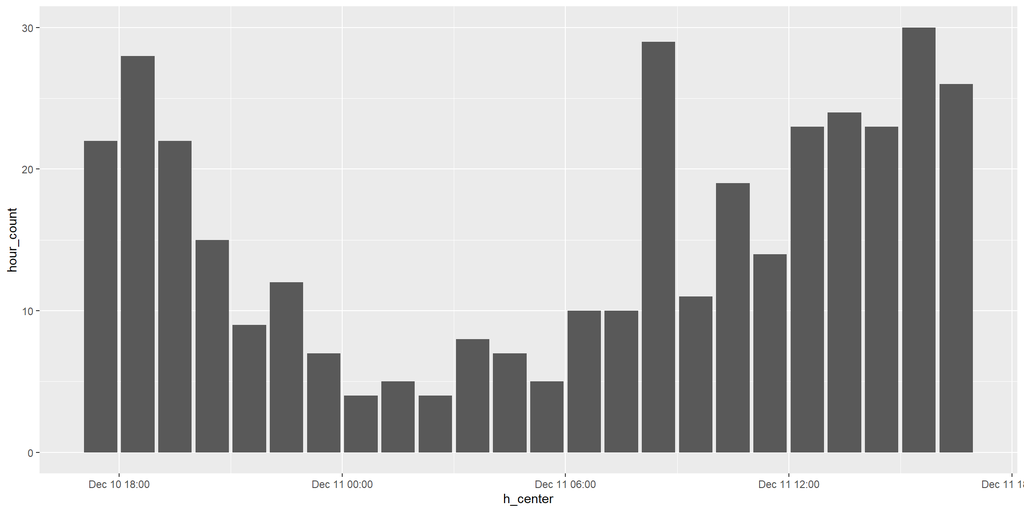

```r
ggplot(data = emergency_hour_count_dt, aes(x = h_center, y = hour_count)) +
  geom_bar(stat = "identity")
```

The bars are now between the hours, rather than on the hours.

### 1.4.2 Using *format_interval()*

1. Set up the data set:

```r
emergency_dt <- data.table::setDT(padr::emergency)
emergency_head_dt <- emergency_dt[title == "EMS: HEAD INJURY"]
head(emergency_head_dt[, .(lat, lng, time_stamp)])
```

```
        lat       lng          time_stamp
1: 40.25347 -75.28324 2015-12-10 17:40:01
2: 40.15528 -75.26423 2015-12-10 18:06:25
3: 40.29527 -75.32840 2015-12-10 20:12:02
4: 40.08820 -75.32664 2015-12-11 00:57:01
5: 40.26418 -75.65600 2015-12-11 04:02:01
6: 40.01177 -75.29467 2015-12-11 04:17:01
```

Raise the time interval to “6 hour”.

```r
emergency_head_dt <- emergency_head_dt %>%
  padr::thicken(interval = "6 hour", colname = "hour6")
head(emergency_head_dt[, .(lat, lng, time_stamp, hour6)])
```

```
        lat       lng          time_stamp               hour6
1: 40.25347 -75.28324 2015-12-10 17:40:01 2015-12-10 12:00:00
2: 40.15528 -75.26423 2015-12-10 18:06:25 2015-12-10 18:00:00
3: 40.29527 -75.32840 2015-12-10 20:12:02 2015-12-10 18:00:00
4: 40.08820 -75.32664 2015-12-11 00:57:01 2015-12-11 00:00:00
5: 40.26418 -75.65600 2015-12-11 04:02:01 2015-12-11 00:00:00
6: 40.01177 -75.29467 2015-12-11 04:17:01 2015-12-11 00:00:00
```

Count the number in each 6 hour interval.

```r
emergency_head_count_dt <- emergency_head_dt[, .(six_hour_count = .N), by = .(hour6)]
head(emergency_head_count_dt, n = 10)
```

```
                  hour6 six_hour_count
 1: 2015-12-10 12:00:00              1
 2: 2015-12-10 18:00:00              2
 3: 2015-12-11 00:00:00              3
 4: 2015-12-11 12:00:00              8
 5: 2015-12-11 18:00:00              2
 6: 2015-12-12 00:00:00              2
 7: 2015-12-12 06:00:00              1
 8: 2015-12-12 12:00:00              4
 9: 2015-12-12 18:00:00              5
10: 2015-12-13 06:00:00              2
```

Pad with missing times and fill NA’s with 0.

```r
emergency_head_count_dt <- emergency_head_count_dt %>%
  pad() %>%
  fill_by_value()
```

```
pad applied on the interval: 6 hour
```

```r
head(emergency_head_count_dt)
```

```
                 hour6 six_hour_count
1: 2015-12-10 12:00:00              1
2: 2015-12-10 18:00:00              2
3: 2015-12-11 00:00:00              3
4: 2015-12-11 06:00:00              0
5: 2015-12-11 12:00:00              8
6: 2015-12-11 18:00:00              2
```

Add variable “hours6_fmt” showing a new time format.

```r
emergency_head_count_dt[, hours6_fmt := padr::format_interval(x = hour6, start_format = "%Hh", sep = "-")]
head(emergency_head_count_dt)
```

```
                 hour6 six_hour_count hours6_fmt
1: 2015-12-10 12:00:00              1    12h-18h
2: 2015-12-10 18:00:00              2    18h-00h
3: 2015-12-11 00:00:00              3    00h-06h
4: 2015-12-11 06:00:00              0    06h-12h
5: 2015-12-11 12:00:00              8    12h-18h
6: 2015-12-11 18:00:00              2    18h-00h
```

Plot the data.

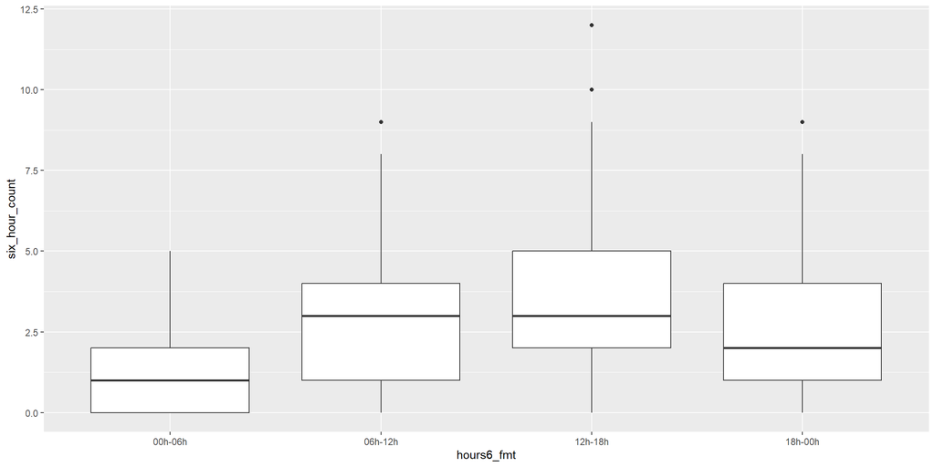

```r
ggplot(data = emergency_head_count_dt, aes(x = hours6_fmt, y = six_hour_count)) +
  geom_boxplot()
```